# MS 6

Rachel Auslander

3/23/2020

[My final project repo](https://github.com/rachelaus/final_project)

[My Shiny app link](https://rachel-auslander.shinyapps.io/news_and_candidates/)

I finished my plot of readers’ ages! I also made a plot to examine readership by race, which makes it look like the dataset is very white. I am going to make a plot based on total participants surveyed rather than just readers to confirm this. I am going to include race distribution of the dataset in its own plot in my final project because I think it is important to contextualize the information that I am presenting and to highlight that the dataset is very white. I think a race-based plot to examine readership would be more informative given the distribution if I plot race along the x axis and the fill is the news source. I made my shiny app and put an image of the age plot in it. I figured out how to render the plot in Shiny instead of adding an image, but my data is not clean enough to make a useful data file to import into the Shiny app yet.

My goals for this upcoming week are to:

- finish cleaning the pubic opinion data
- finish public opinion plots (comparing news sources to stances on different issues)
- scrape my headline data
- clean the headline data so i can work with it
- make at least one headline related plot
- clean up my final project github

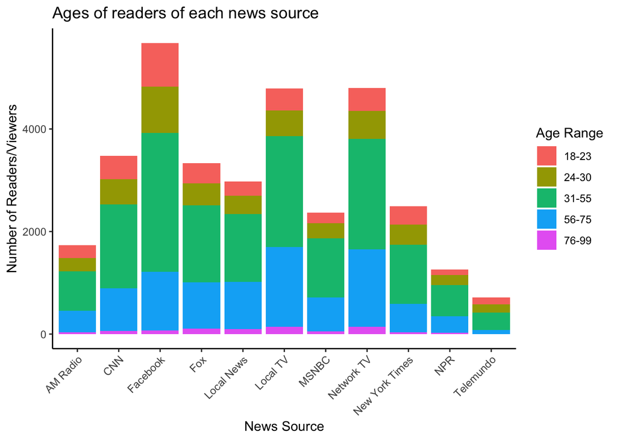

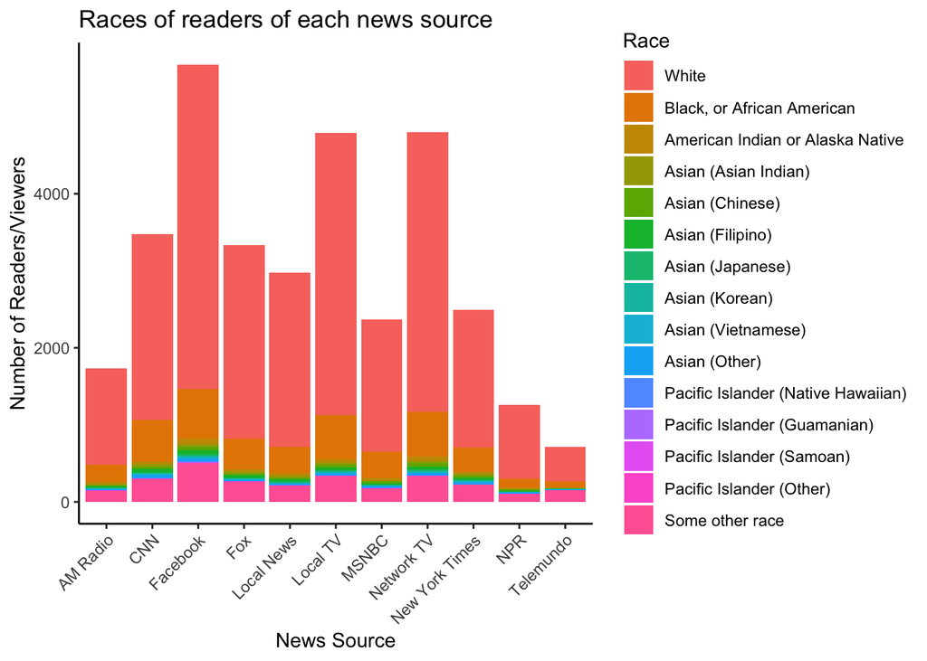